# PSTAT 126 Final Project

Daniel Larson, Emanuel Rodriguez

2025-12-09

The first objective is to understand the variables in your dataset and their relationships. Your task is to choose a dataset Diamonds from Kaggle: Here’s the link. You should include atleast 2 categorical variables and 3 independent quantities

# Part 1: Data Description and Descriptive Statistics

Requirements: Include at least 2 categorical variables and 3 independent quantities.

## 1. Select a random sample (must have 500 observations):

```r
filepath <- "/Users/daniellarson/Downloads/Diamonds Prices2022.csv"
df <- read.csv(filepath)

set.seed(777)
sample_df <- df[sample(nrow(df), 500), ]
```

## 2. Describe all the variables(call summary function on the dataset, see the structure, create histograms for continuous random variable, comment on their distribution, bar plots for categorical random variable)

```r
summary(sample_df)
```

```
##        X             carat            cut               color
##  Min.   :  130   Min.   :0.2100   Length:500         Length:500
##  1st Qu.:13193   1st Qu.:0.4200   Class :character   Class :character
##  Median :25246   Median :0.7250   Mode  :character   Mode  :character
##  Mean   :25858   Mean   :0.8303
##  3rd Qu.:38800   3rd Qu.:1.0600
##  Max.   :53853   Max.   :3.0100
##    clarity              depth           table           price
##  Length:500         Min.   :56.10   Min.   :53.00   Min.   :  386
##  Class :character   1st Qu.:61.17   1st Qu.:56.00   1st Qu.: 1008
##  Mode  :character   Median :61.90   Median :57.00   Median : 2858
##                     Mean   :61.78   Mean   :57.43   Mean   : 4207
##                     3rd Qu.:62.60   3rd Qu.:59.00   3rd Qu.: 5884
##                     Max.   :66.60   Max.   :65.00   Max.   :17904
##        x               y               z
##  Min.   :3.870   Min.   :3.830   Min.   :2.330
##  1st Qu.:4.800   1st Qu.:4.810   1st Qu.:2.990
##  Median :5.810   Median :5.830   Median :3.590
##  Mean   :5.823   Mean   :5.823   Mean   :3.596
##  3rd Qu.:6.565   3rd Qu.:6.590   3rd Qu.:4.050
##  Max.   :9.540   Max.   :9.380   Max.   :5.340
```

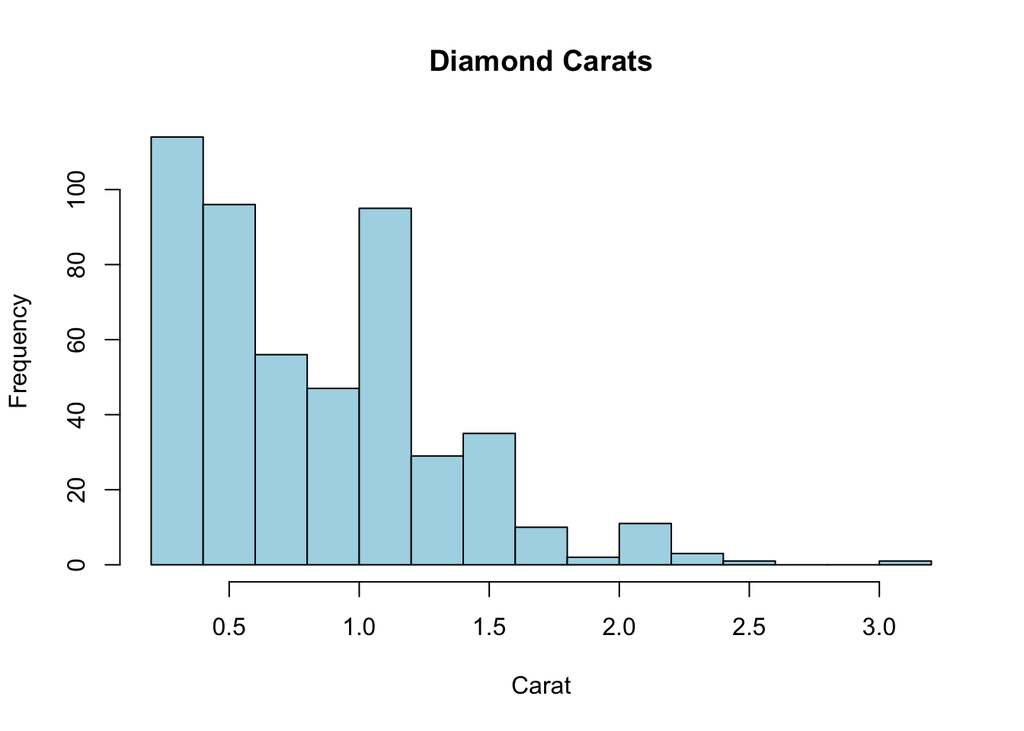

```r
# Carat
hist(sample_df$carat,
     main = "Diamond Carats",
     xlab = "Carat",
     ylab = "Frequency",
     col = "lightblue",
     border = "black")
```

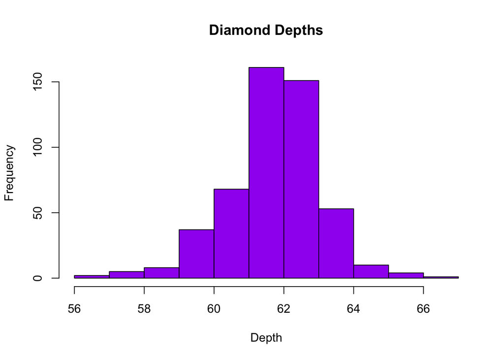

```r
# Depth
hist(sample_df$depth,
     main = "Diamond Depths",
     xlab = "Depth",
     ylab = "Frequency",
     col = "purple",
     border = "black")
```

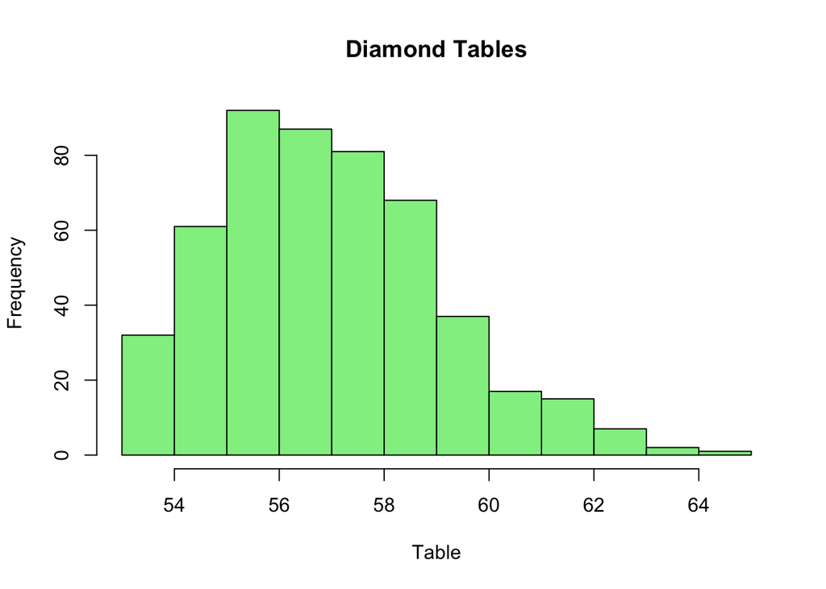

```r
# Table
hist(sample_df$table,
     main = "Diamond Tables",
     xlab = "Table",
     ylab = "Frequency",
     col = "lightgreen",
     border = "black")
```

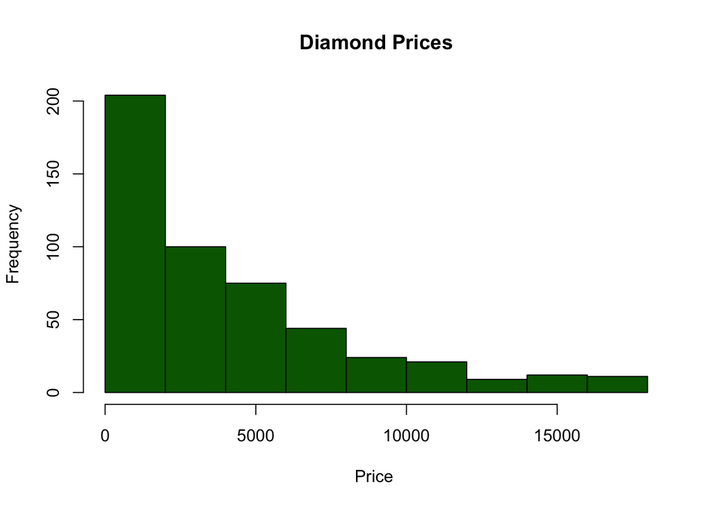

```r
# Price
hist(sample_df$price,
     main = "Diamond Prices",
     xlab = "Price ",
     ylab = "Frequency",
     col = "darkgreen",
     border = "black")
```

Table: The table distribution is slightly right-skewed. Most values are clustered between 54–60, with around 55 being the most common. This suggests that the majority of diamonds fall within a standard table proportion range.

Prices: Price is heavily right-skewed. Most diamonds in the sample cost under $5,000, but there is a long upper tail with many diamonds priced above $10,000. This pattern is expected because a small number of diamonds are very expensive. There aren’t any extreme outliers beyond this tail, so the distribution looks reasonable.

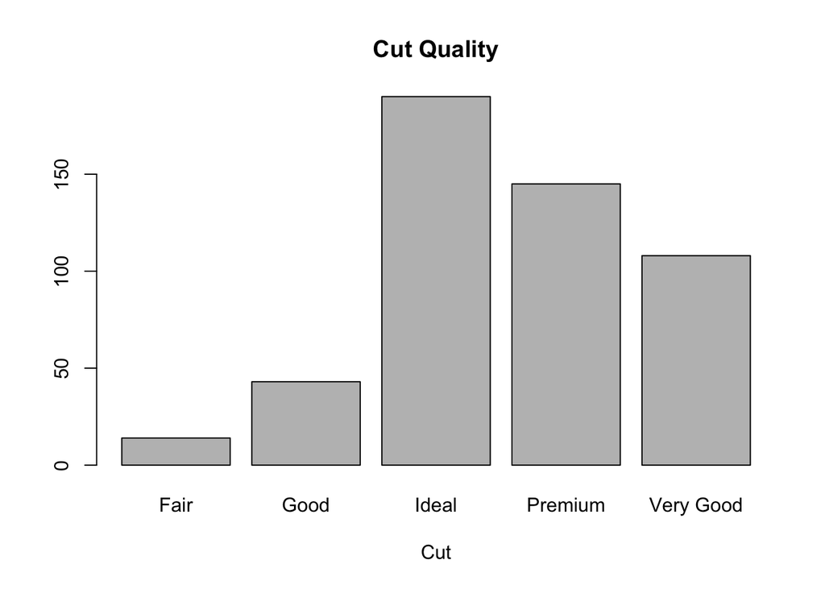

```r
#Barplot's

#Cut
barplot(table(sample_df$cut), main="Cut Quality", xlab="Cut") # nolint
```

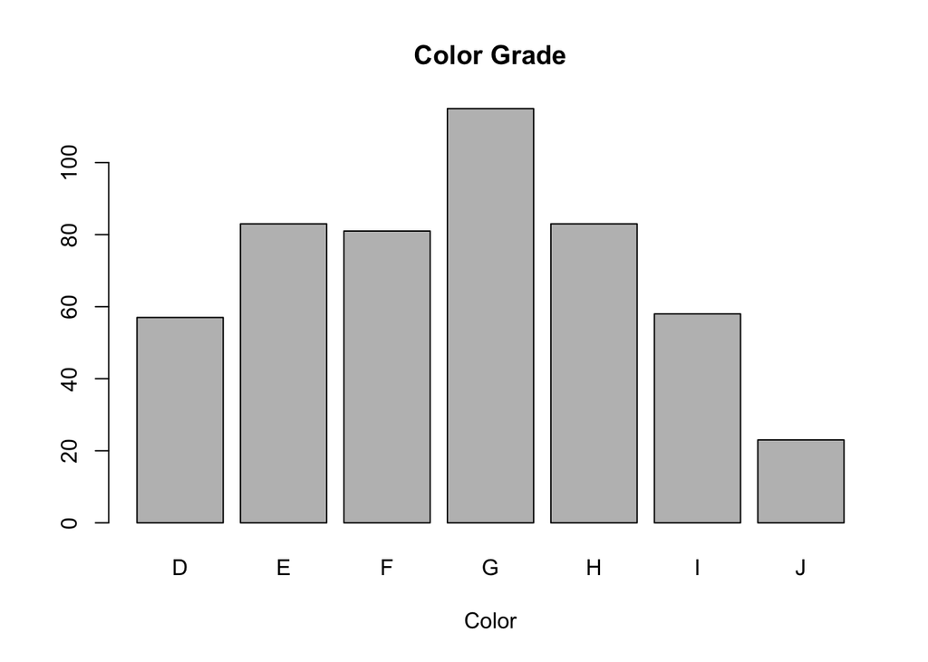

```r
#Color
barplot(table(sample_df$color), main="Color Grade", xlab="Color") # nolint
```

## 3. Choose 3 quantitative and 2 categorical variables appropriately and determine if there is any correlation between these variables.

```r
#Variables
quant_vars <- sample_df[, c("table", "carat", "depth")]

cor(quant_vars)
```

```
##            table       carat       depth
## table  1.0000000  0.25164918 -0.33747879
## carat  0.2516492  1.00000000 -0.08903546
## depth -0.3374788 -0.08903546  1.00000000
```

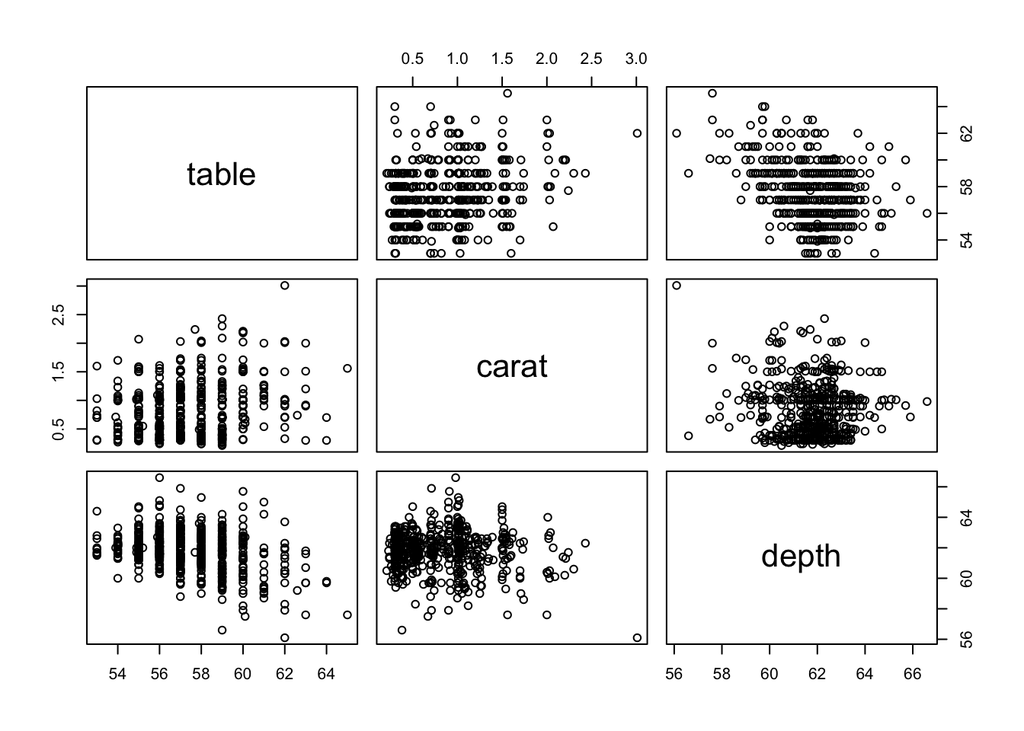

```r
pairs(quant_vars)
```

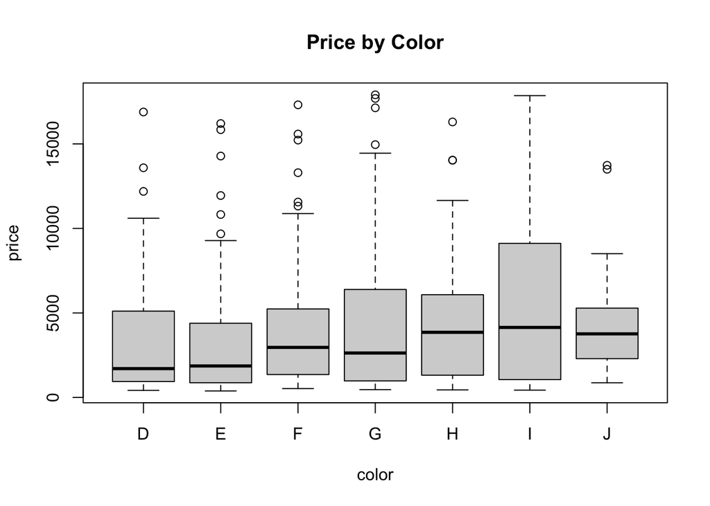

```r
boxplot(price ~ color,
        data = sample_df,
        main = "Price by Color")
```

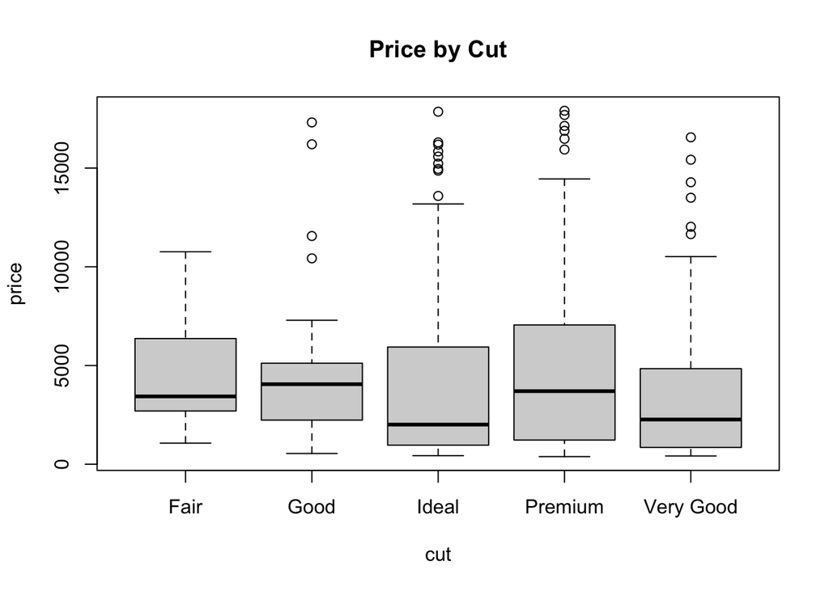

```r
boxplot(price ~ cut,
        data = sample_df,
        main = "Price by Cut")
```

Comments on correlation:

As a whole, carat seems to be the biggest impact on price generally, whereas on the otherside, depth and table do not show too much correlations in the scatterplots. However, the color and cut, categorial variables, also appears to influence the price depending on how the boxplots different across groups.

## 4.Run multiple linear regression model using all these variables and observe the summary statistics. (No need to explain hypothesis testing or other things)

```r
diamondmodel <- lm(price ~ color + cut + carat + depth + table, data = sample_df)
summary(diamondmodel)
```

```
##
## Call:
## lm(formula = price ~ color + cut + carat + depth + table, data = sample_df)
##
## Residuals:
##     Min      1Q  Median      3Q     Max
## -8521.0  -723.0  -112.3   551.1  6573.3
##
## Coefficients:
##              Estimate Std. Error t value Pr(>|t|)
## (Intercept)  -8151.41    5127.63  -1.590  0.11255
## colorE        -136.74     250.51  -0.546  0.58544
## colorF        -254.14     252.22  -1.008  0.31414
## colorG         -84.36     235.21  -0.359  0.72001
## colorH       -1078.81     251.85  -4.283 2.22e-05 ***
## colorI       -1158.57     276.12  -4.196 3.23e-05 ***
## colorJ       -2184.47     362.49  -6.026 3.32e-09 ***
## cutGood       1451.49     463.94   3.129  0.00186 **
## cutIdeal      2329.69     444.17   5.245 2.34e-07 ***
## cutPremium    1922.74     436.21   4.408 1.29e-05 ***
## cutVery Good  1967.59     434.22   4.531 7.39e-06 ***
## carat         8432.71     150.31  56.102  < 2e-16 ***
## depth           98.01      56.98   1.720  0.08606 .
## table          -38.20      42.25  -0.904  0.36627
## ---
## Signif. codes:  0 '***' 0.001 '**' 0.01 '*' 0.05 '.' 0.1 ' ' 1
##
## Residual standard error: 1444 on 486 degrees of freedom
## Multiple R-squared:  0.8751, Adjusted R-squared:  0.8718
## F-statistic: 261.9 on 13 and 486 DF,  p-value: < 2.2e-16
```

## 5. comment on anything of interest that occurred in this part. Were the data approximately what you expected, or did some of the results surprise you?

- The results were generally consistent with expectations. Carat size was the strongest predictor of price, with larger diamonds commanding substantially higher prices. Higher cut quality was associated with increased price, while lower color grades led to significant price reductions. One result that was surprising to me was that the table variable was not statistically significant once other predictors were included, suggesting its effect is absorbed by related measures such as depth and cut. Overall though, the data behaved as expected and supported known drivers of diamond pricing.

# Part 2: Simple Linear Regression (continuation of Part 1)

## 2. Run the model and examine the summary statistics, interpreting everything (hypothesis testing, adjusted R-squared as discussed in class, confidence interval, prediction interval, plot, etc.).

```r
model_simple <- lm(price ~ carat, data = sample_df)
summary(model_simple)
```

```
##
## Call:
## lm(formula = price ~ carat, data = sample_df)
##
## Residuals:
##      Min       1Q   Median       3Q      Max
## -10692.6   -853.7    -36.6    586.0   7563.4
##
## Coefficients:
##             Estimate Std. Error t value Pr(>|t|)
## (Intercept)  -2362.5      144.9  -16.30   <2e-16 ***
## carat         7912.3      152.1   52.03   <2e-16 ***
## ---
## Signif. codes:  0 '***' 0.001 '**' 0.01 '*' 0.05 '.' 0.1 ' ' 1
##
## Residual standard error: 1591 on 498 degrees of freedom
## Multiple R-squared:  0.8446, Adjusted R-squared:  0.8443
## F-statistic:  2707 on 1 and 498 DF,  p-value: < 2.2e-16
```

Full interpretation:

Model: $price_i$ = $\beta_0$ + $\beta_1$($carat_i$) + $\epsilon_i$

Hypothesis Tests: H0 = $\beta_1$ = 0 (carat has no linear effect on price) HA = $\beta_1$ =/= 0 (carat affects price)

The estimated slope for carat is 7912.3 , indicating that for each additional carat, the expected diamond price increases by approximately $7912 on average. The hypothesis test for the slope yields a p-value less than 2*(10^-16), leading to rejection of the null hypothesis because the p-value is less than any reasonable significance level. This confirms that carat is a statistically significant predictor of price.

The Confidence Interval:

```r
new_carat <- data.frame(carat = 1)

predict(model_simple, new_carat, interval = "confidence")
```

```
##        fit      lwr      upr
## 1 5549.867 5401.129 5698.605
```

Interpretation for CI: For a diamond with the specified carat value, the estimated mean price is approximately 5550 dollars, with the 95% confidence interval for this mean price being (5401, 5699). This relatively narrow interval reflects the precision of the estimated regression line and indicates that the average price at this carat level is estimated with fairly high confidence.

The Prediction Interval:

```r
predict(model_simple, new_carat, interval = "prediction")
```

```
##        fit      lwr     upr
## 1 5549.867 2419.655 8680.08
```

Interpretation for PI: For a single new diamond of the same carat size, the predicted price is also 5550 dollars, but the 95% prediction interval is much wider: (2420, 8680). This wider interval is accunting not only for uncertainty in estimating the regression line but also for the natural variability in individual diamond prices. This highlights that while the mean price can be estimated precisely, individual diamond prices can vary substantially despite having the same carat level.

Plot with fitted regression line:

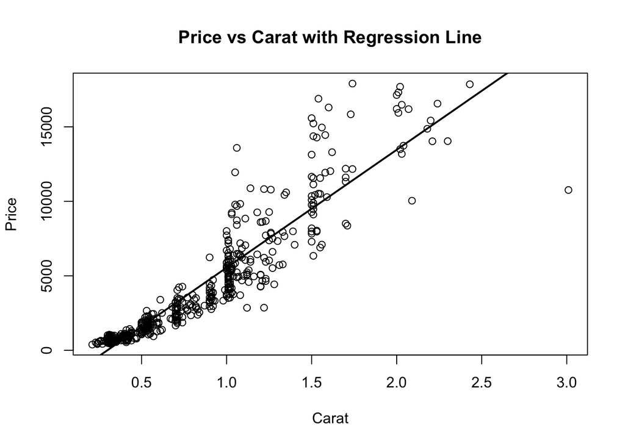

```r
plot(sample_df$carat, sample_df$price,
     xlab = "Carat",
     ylab = "Price",
     main = "Price vs Carat with Regression Line")

abline(model_simple, lwd = 2)
```

The scatterplot line shows that there is a strong positive linear relationship between carat and price. Additionally, points are centered close around the regression line, which shows a high R^2 support. Variability tends to increase for larger diamond with more vertical spread, typical among heteroscedastic pricing data.

## 3.Test the assumptions and apply any necessary transformations to the response variable y or the predictor.

Original model diagnostics:

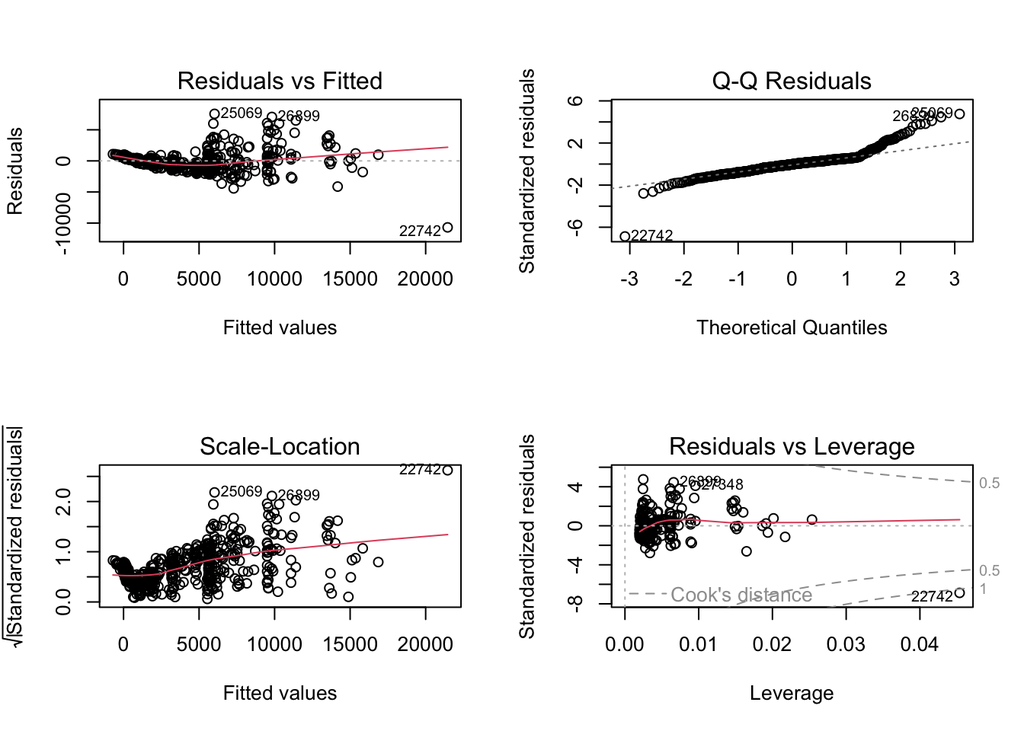

```r
par(mfrow=c(2,2))
plot(model_simple)
```

```r
par(mfrow=c(1,1))
log_model <- lm(log(price) ~ carat, data = sample_df)
```

## 4. Call the summary function on the transformed variables, observe the summary, and note any changes.

```r
summary(log_model)
```

```
##
## Call:
## lm(formula = log(price) ~ carat, data = sample_df)
##
## Residuals:
##      Min       1Q   Median       3Q      Max
## -2.90905 -0.23163  0.02578  0.25810  1.18424
##
## Coefficients:
##             Estimate Std. Error t value Pr(>|t|)
## (Intercept)  6.23443    0.03549  175.65   <2e-16 ***
## carat        1.97950    0.03724   53.16   <2e-16 ***
## ---
## Signif. codes:  0 '***' 0.001 '**' 0.01 '*' 0.05 '.' 0.1 ' ' 1
##
## Residual standard error: 0.3897 on 498 degrees of freedom
## Multiple R-squared:  0.8502, Adjusted R-squared:  0.8499
## F-statistic:  2826 on 1 and 498 DF,  p-value: < 2.2e-16
```

## 5. Add other variables to the model and assess if the model improves. For step 5, run the code in the background and include all interpretations in the file. For instance, if adding depth to the simple linear regression model (carat and price) increases the adjusted R^2, include it in the model; if it decreases, exclude it. Do not include the code for step 5 in the submitted file; only write the conclusions.

```
##      base        m2        m3        m4        m5
## 0.8498601 0.8519611 0.8678846 0.8714167 0.8713216
```

## 6. Comment anything of interest while doing this.

While coding the models, it was clear that carat is the strongest predictor of price, as expected. Adding depth, color, and cut steadily improved the adjusted R-squared, showing that quality characteristics also play a meaningful role. Interestingly, adding table had almost no effect, suggesting it is less important for predicting price. The log transformation of price helped stabilize variance and made the residuals more symmetric. Overall, the results matched expectations, but it was notable how much cut and color contributed beyond just size.

# Part 3: Part 2 Continutation…

## 1. Based on the best model obtained from Part II (you would have more than one variable now), run it and call the summary function to analyze how it works and what you observe.

## 2. Detect multicollinearity among the variables using the variance inflation factor (VIF)

## 3. Give CIs for a mean predicted value and the PIs of a future predicted value for at least one combination of X’s (from your final linear model).

Using approach 1, we can answer ALL #1 and #2 and #3 of Part 3:

Add all remaining variables to the simple regression model you have obtained in part-2 after transformation. Use AIC/BIC to avoid overfitting, check variance inflation factor (VIF) for multicollinearity, and ensure model assumptions are satisfied (you have to check model assumptions again in this part after adding all the other variables).

Compute confidence intervals, prediction intervals, and summarize your report clearly.

```r
bestmodel <- lm(log(price) ~ carat + depth + table + color + cut + clarity, data = sample_df)
summary(bestmodel)
```

```
##
## Call:
## lm(formula = log(price) ~ carat + depth + table + color + cut +
##     clarity, data = sample_df)
##
## Residuals:
##      Min       1Q   Median       3Q      Max
## -1.77887 -0.19978  0.05101  0.22326  0.80092
##
## Coefficients:
##               Estimate Std. Error t value Pr(>|t|)
## (Intercept)   3.500615   1.164762   3.005  0.00279 **
## carat         2.217139   0.036143  61.343  < 2e-16 ***
## depth         0.028203   0.013198   2.137  0.03310 *
## table        -0.007769   0.009534  -0.815  0.41551
## colorE       -0.045015   0.056615  -0.795  0.42694
## colorF        0.010798   0.057067   0.189  0.85000
## colorG       -0.090524   0.054586  -1.658  0.09790 .
## colorH       -0.212145   0.057490  -3.690  0.00025 ***
## colorI       -0.451494   0.062719  -7.199 2.37e-12 ***
## colorJ       -0.380062   0.081839  -4.644 4.42e-06 ***
## cutGood       0.207604   0.105644   1.965  0.04998 *
## cutIdeal      0.208290   0.101938   2.043  0.04157 *
## cutPremium    0.191020   0.099698   1.916  0.05596 .
## cutVery Good  0.171059   0.099499   1.719  0.08622 .
## clarityIF     1.541263   0.190415   8.094 4.79e-15 ***
## claritySI1    1.136220   0.172848   6.574 1.29e-10 ***
## claritySI2    0.957326   0.171872   5.570 4.25e-08 ***
## clarityVS1    1.293815   0.174882   7.398 6.23e-13 ***
## clarityVS2    1.229676   0.171928   7.152 3.21e-12 ***
## clarityVVS1   1.284112   0.181152   7.089 4.88e-12 ***
## clarityVVS2   1.378685   0.178530   7.722 6.72e-14 ***
## ---
## Signif. codes:  0 '***' 0.001 '**' 0.01 '*' 0.05 '.' 0.1 ' ' 1
##
## Residual standard error: 0.3242 on 479 degrees of freedom
## Multiple R-squared:  0.9002, Adjusted R-squared:  0.8961
## F-statistic: 216.1 on 20 and 479 DF,  p-value: < 2.2e-16
```

```r
# Now applying AIC/BIC, and VIF and checking assumptions of model
AIC(bestmodel)
```

```
## [1] 315.2053
```

```r
BIC(bestmodel)
```

```
## [1] 407.9267
```

```r
library(car)
vif(bestmodel)
```

```
##             GVIF Df GVIF^(1/(2*Df))
## carat   1.360832  1        1.166547
## depth   1.488309  1        1.219963
## table   2.007385  1        1.416822
## color   1.356200  6        1.025716
## cut     2.371372  4        1.113974
## clarity 1.622218  7        1.035161
```

```r
confint(bestmodel)
```

```
##                      2.5 %      97.5 %
## (Intercept)   1.211940e+00  5.78929006
## carat         2.146119e+00  2.28815793
## depth         2.270908e-03  0.05413554
## table        -2.650247e-02  0.01096359
## colorE       -1.562585e-01  0.06622854
## colorF       -1.013338e-01  0.12292967
## colorG       -1.977819e-01  0.01673366
## colorH       -3.251081e-01 -0.09918093
## colorI       -5.747334e-01 -0.32825533
## colorJ       -5.408697e-01 -0.21925378
## cutGood       2.090368e-05  0.41518686
## cutIdeal      7.989141e-03  0.40859000
## cutPremium   -4.879499e-03  0.38692017
## cutVery Good -2.444959e-02  0.36656786
## clarityIF     1.167111e+00  1.91541584
## claritySI1    7.965849e-01  1.47585485
## claritySI2    6.196097e-01  1.29504143
## clarityVS1    9.501839e-01  1.63744590
## clarityVS2    8.918494e-01  1.56750171
## clarityVVS1   9.281611e-01  1.64006315
## clarityVVS2   1.027885e+00  1.72948453
```

```r
new_obs <- data.frame(carat = 1, depth = 61, table = 57, color = "G", cut = "Ideal", clarity = "VS2")
predict(bestmodel, newdata = new_obs, interval = "confidence")
```

```
##        fit      lwr      upr
## 1 8.342733 8.249651 8.435815
```

```r
predict(bestmodel, newdata = new_obs, interval = "prediction")
```

```
##        fit      lwr    upr
## 1 8.342733 7.698866 8.9866
```

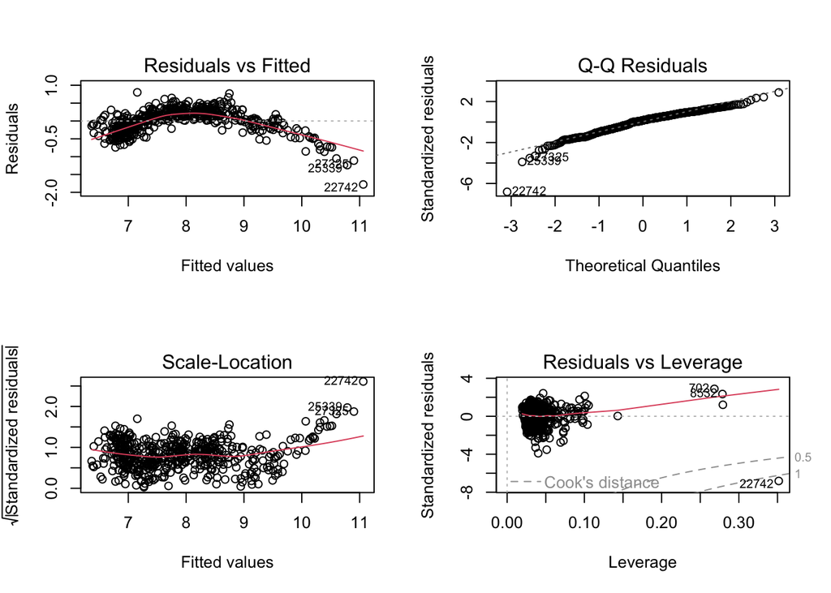

```r
par(mfrow = c(2,2))
plot(bestmodel)
```

## 4. Summarize your report (for the final deliverable).

In this final project we took a deep, analytical look at the Diamonds dataset to see how different types of characteristics in a diamond affect pricing. We took a random sample of 500 diamonds to examine these characteristics through summary statistics and visualizations, and the data we found was quite intriguing. We saw that carat was the biggest indicator that it had the strongest relationship with price from these models, while other characteristics such color and depth had less obvious correlations

In summary, the analysis showed how various diamond attributes interact to influence price, highlighted how important model comparisons are, and shows the value of transformations and diagnostics in building the most effective regression model.